# Analyzing Pilot Results

# Setup: load data, define variables, etc

# Do all the calculations of all the dependent variables

Create a giant, long form data with dependent variables being performance on each of the 8 repetition of PAs. Factors will include:

- condition
- accuracy_type: i.e. how wide is the accuracy box/radius
- neighbor_status: is the dependent variable reflecting performance on the neighbor PAs, island PAs, or collapsed over them?

## Fit the learning curve, with intercept and learning rate

## Rough measures of learning: last 2 or last 4 reps of PAs

# Learning curve plots

## Raw learning curves, without the fitted data

This is helpful to compare which accuracy radii to use.

Below, I plot only:

- correct_exact
- correct_rad_42
- correct_rad_63
- correct_one_square_away

We can see that, correct_exact is lowest, then comes correct_rad_42, and the correct_rad_63 and correct_one_square_away are almost exactly overlapping.

I suggest we use the correct_exact and the correct_one_square_away measures.

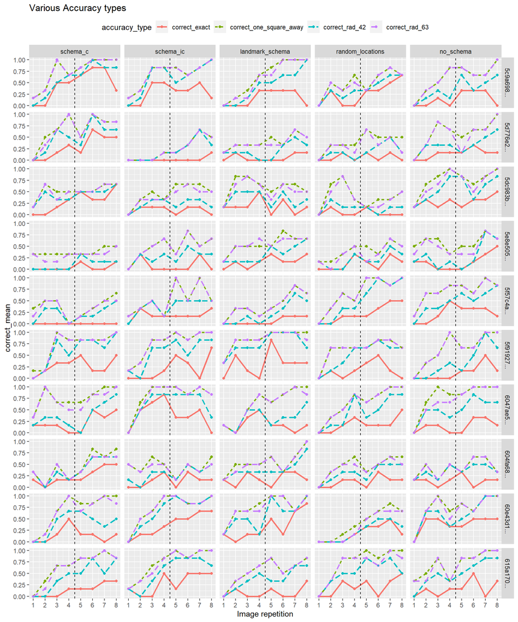

## Raw learning curves + learning fits

So, overlay the curve fits, with annotated info about the intercept value, learning rate value, and convergence status. For the convergence status:

- 0 means success
- 52 means error.

Only plot correct_exact and then correct_one_square_away. Two separate panels of plots for each.

Looking at those participants where the convergence failed, its unclear why it happens. For some of the failure cases, the data doesn’t look messy or weird in any way. For example, participant ‘6047ae5…’ random_locations condition, one_square_away measure.

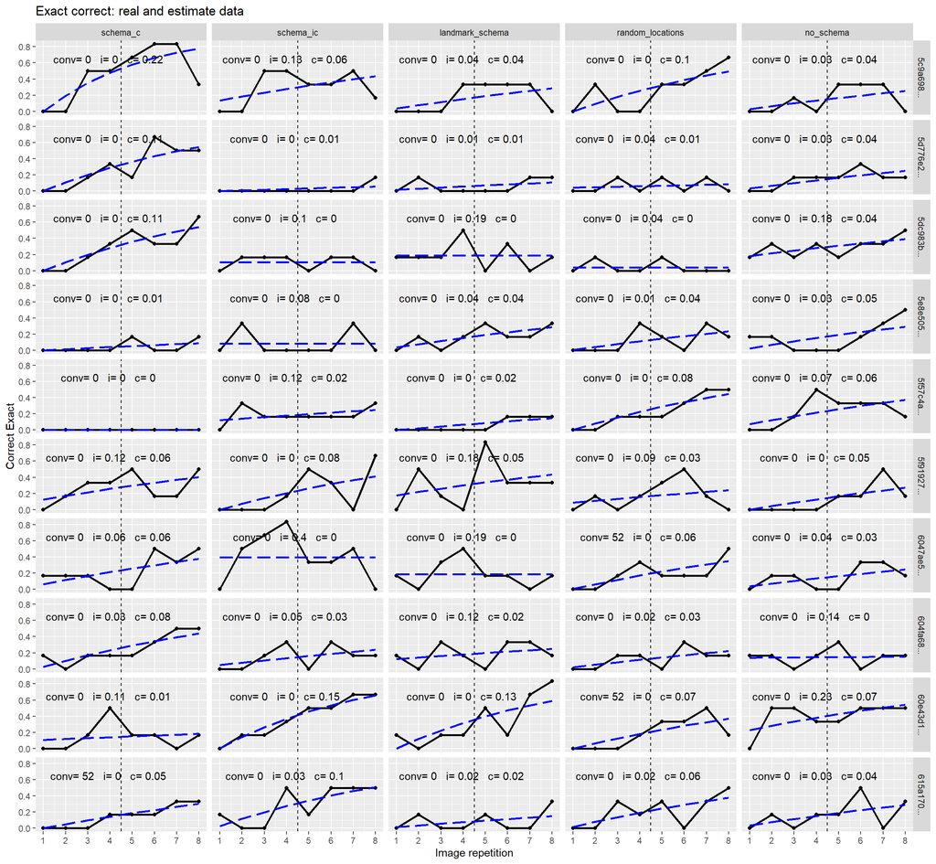

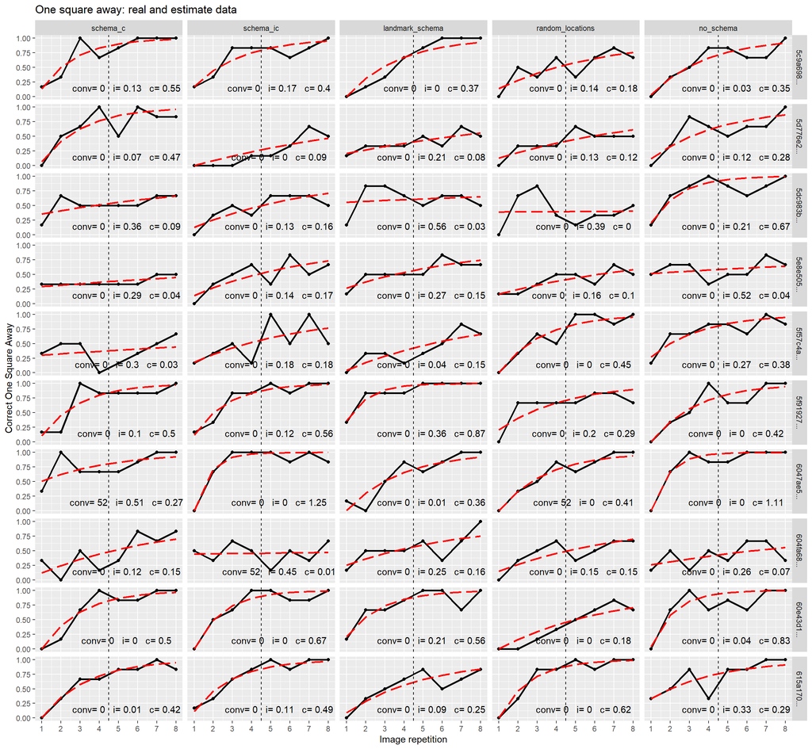

## Learning curves: Landmark vs non-landmark

Neighbor PAs are coded as “neighbor”. Non-neighbor PAs are coded as “island”.

Again, two panels of plots for the two dependent variables: “exact correct” and “correct one square away”.

We can see convergence in all but 1 case: 5d776e2… landmark_schema, one_square_away.

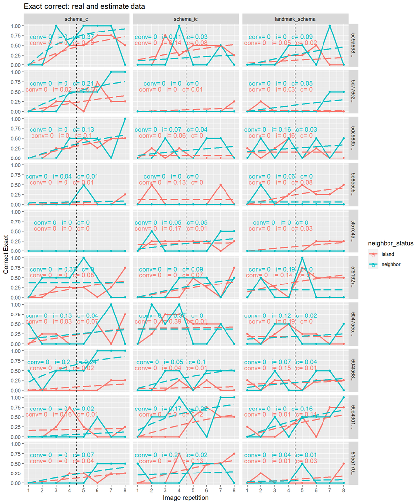

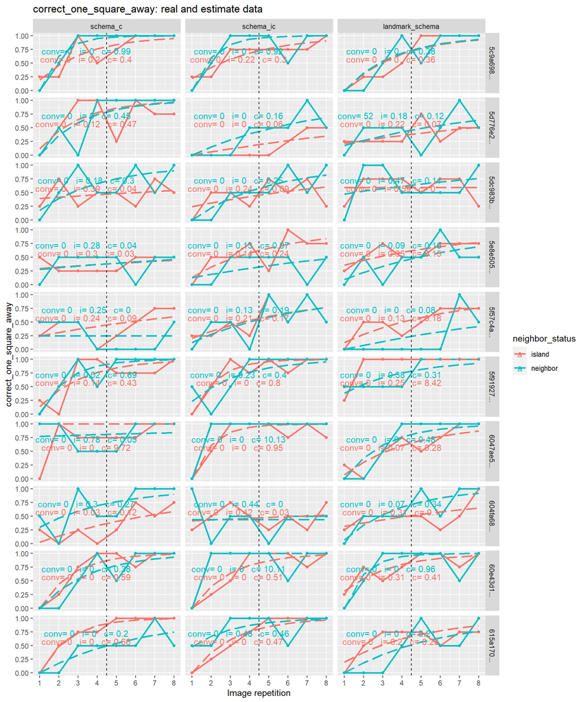

# Scatter plots of dependent variables:

## Rough measures: last 2 reps and last 4 reps

### Over all trials:

I think the last 2 reps is a better dependent variable, because it captures better the “final” state of learning.

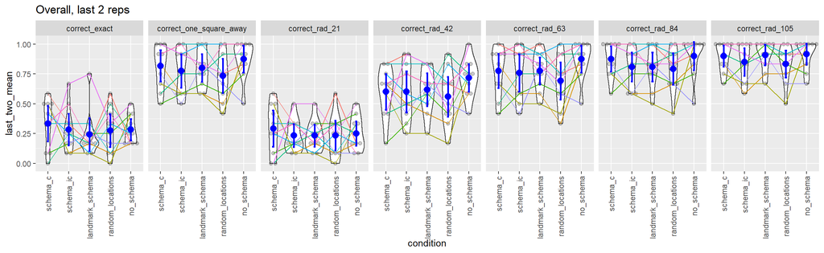

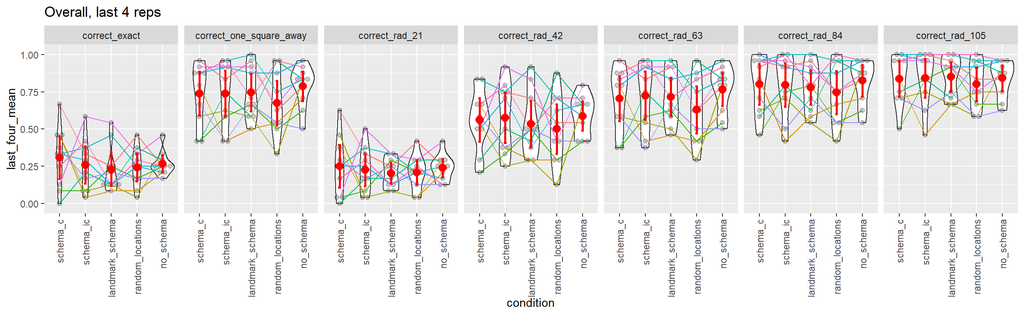

Also plot different accuracy types, within each condition. Illustrates nicely how the performance grows.

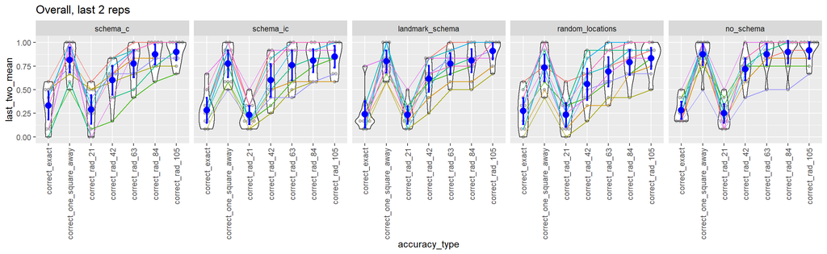

### Which is more Gaussian?

Conclusion: no drastic difference.

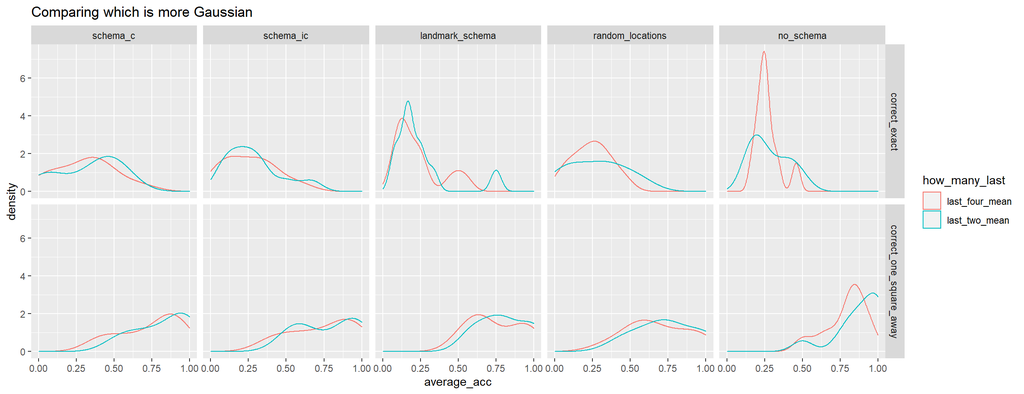

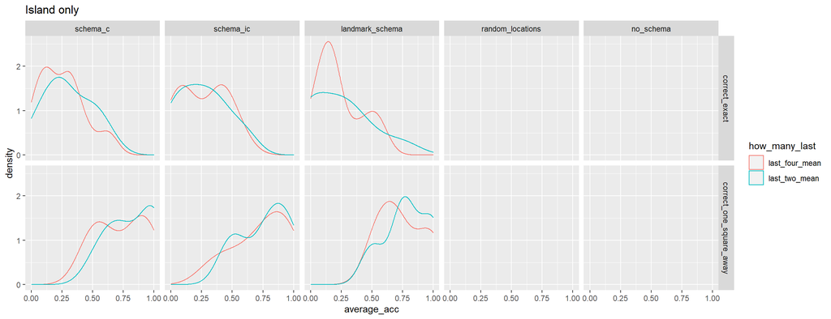

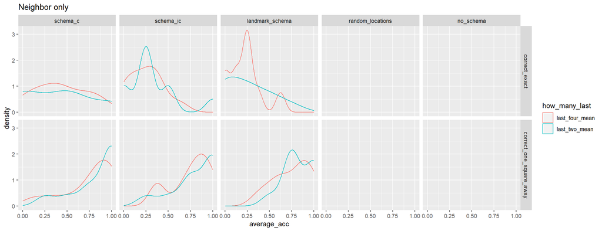

### Island vs Neighbor:

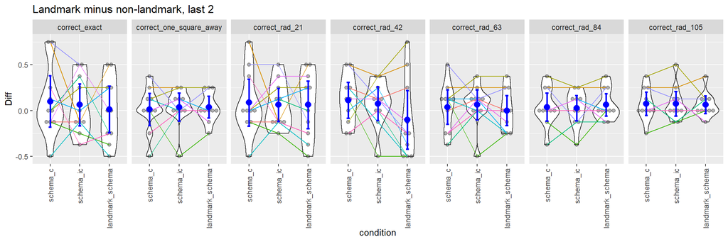

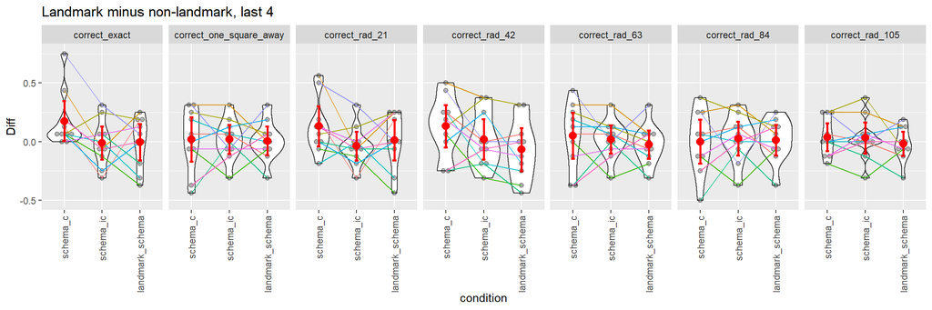

Conclusions from this section:

- Use the average of last 2 reps as the “rough” measure of learning.
- Use correct_exact and correct_one_square_away measures.
- Landmark-vs-non-landmark doesn’t seem to show any strong differences on the plots.

## Learning rates:

### Over all trials:

We see reasonable values:

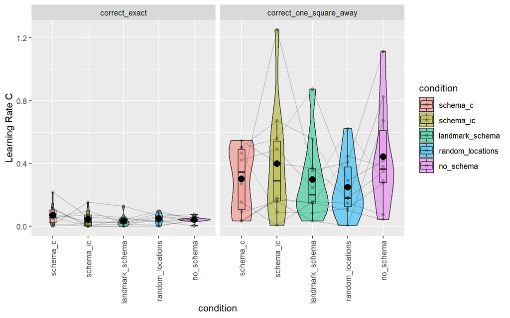

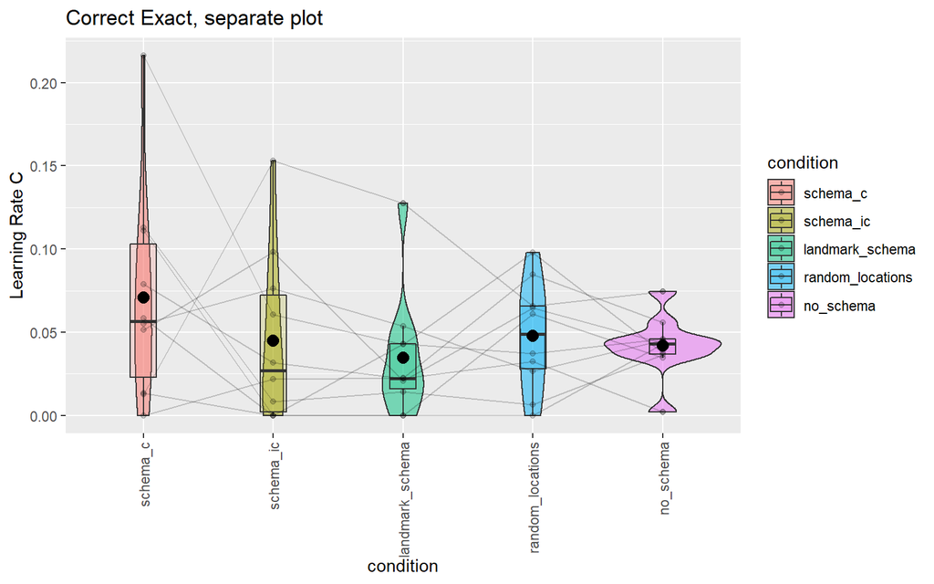

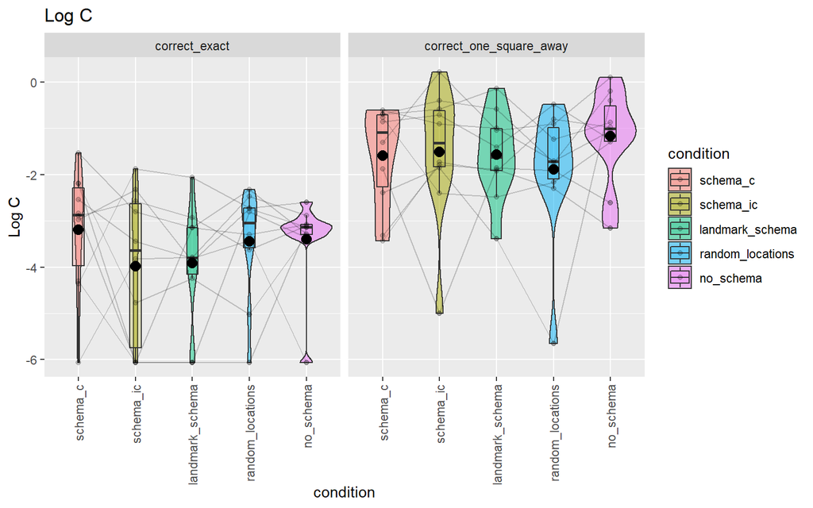

### Island vs Neighbor:

First, plot the island and neighbor values on separate plots:

We see that for correct_one_square_away we get some “outlier” learning rate parameter estimates.

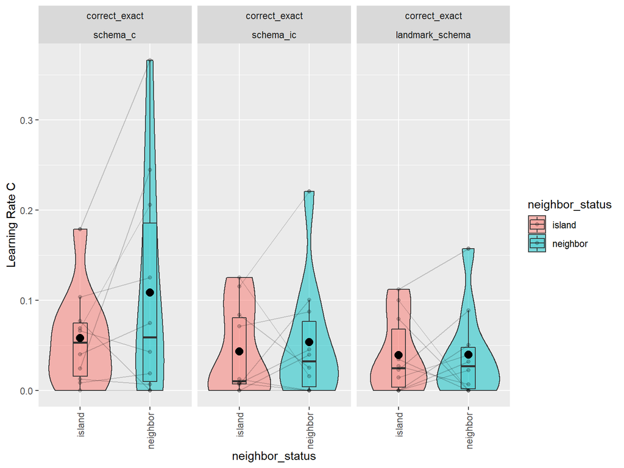

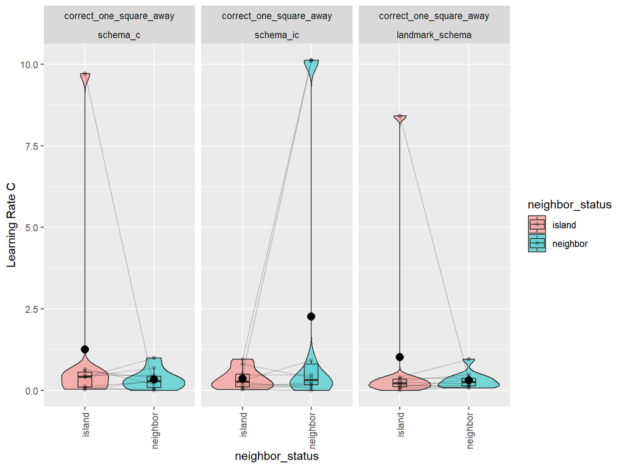

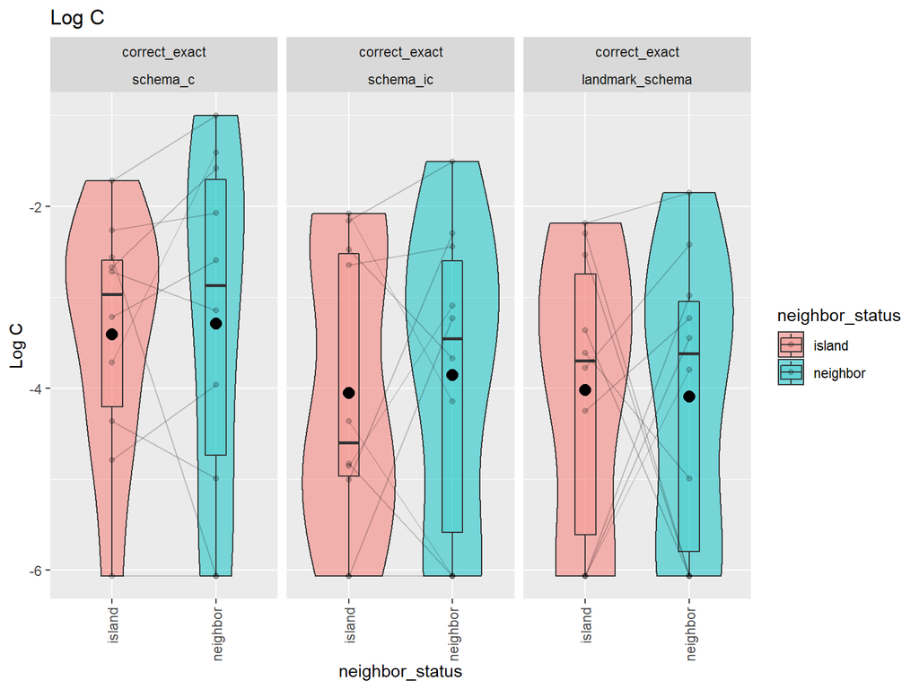

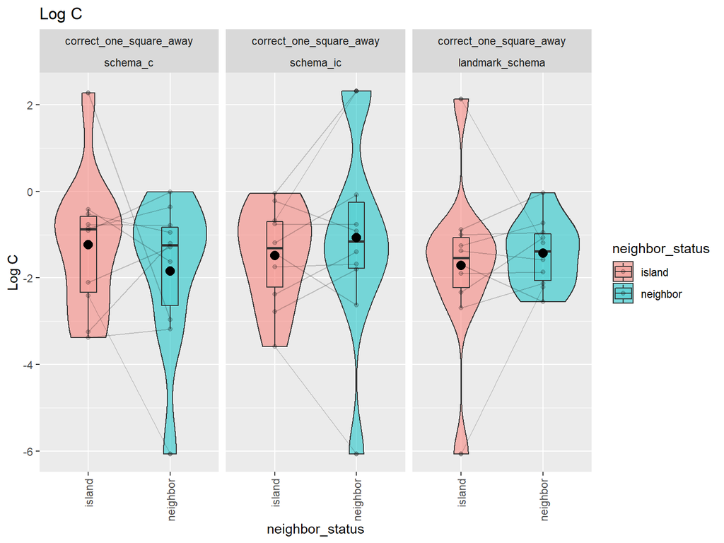

Plot the difference values:

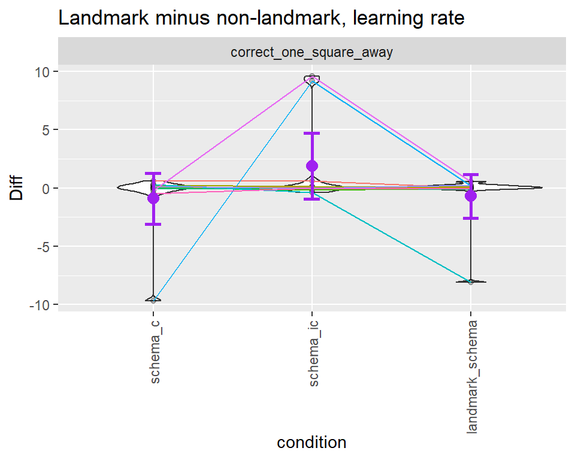

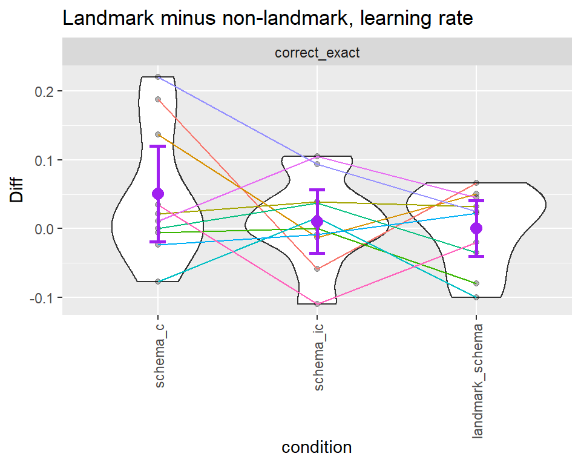

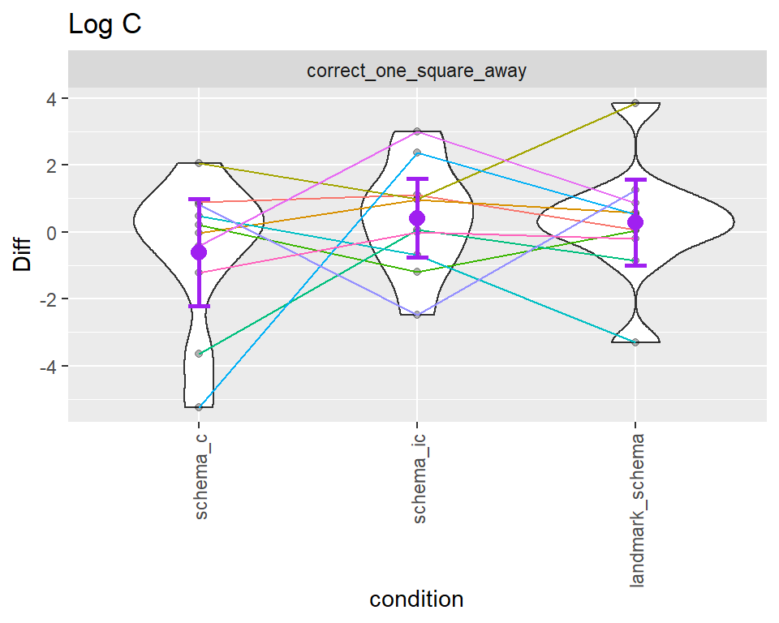

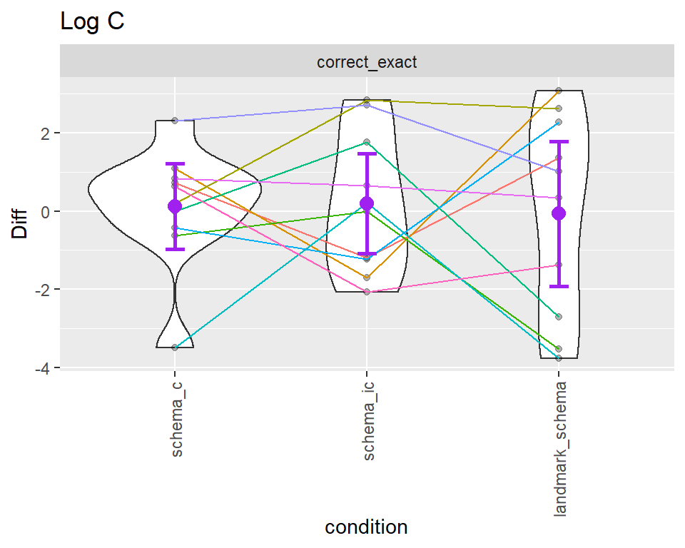

# Examine basic stats:

## Landmark > non-landmark

### Learning Rate

How many participants had the learning rate larger for landmark-neighbors vs non-neighbors?

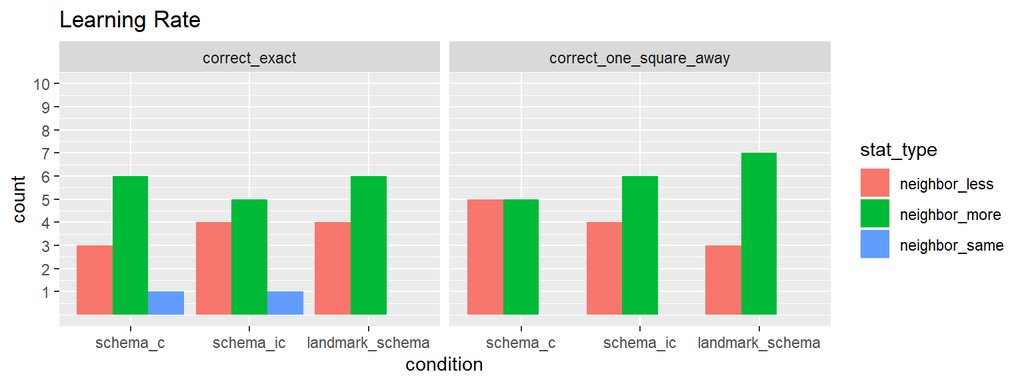

### Last two reps

Same for last two reps

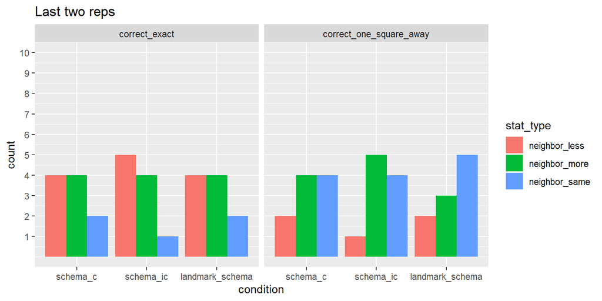

### Last four reps

Same for last four reps

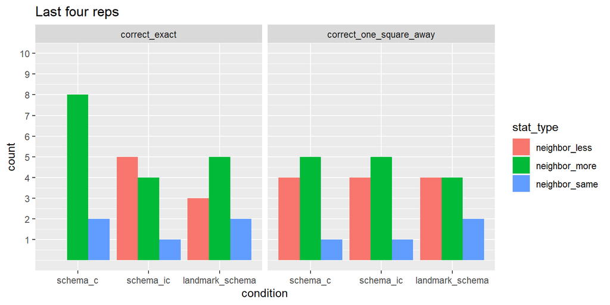